# Question

A circle is centered at the origin with a radius equal to 1. This circle is called [the unit circle](https://en.wikipedia.org/wiki/Unit_circle), where “unit” refers to 1.

A **horizontal** line passes through point $(0.16,0.29)$.

That horizontal line intersects the circle at two points: one in Quadrant I and another in Quadrant II.

Determine the $x$-coordinate of the intersection between the line and the circle in Quadrant I.

Please be accurate within $\pm 0.001$.

# Solution

The general form of a circle:

$$(x-h)^2+(y-k)^2~=~r^2$$

We were told the center is $(0,0)$ and radius is 1. So, the equation of the unit circle:

$$(x-0)^2+(y-0)^2=1^2$$

$$x^2+y^2=1$$

The general form of a horizontal line:

$$y=c$$

In our case, because the line hits point $(0.16,0.29)$ we know the horizontal line should include every point where $y$ equals 0.29.
$$y=0.29$$

So, to find the other coordinate of the intersection, replace y with 0.29 in the unit-circle equation. Solve for x.

$$x^2+0.29^2=1$$
$$x^2=1-0.29^2$$
$$x=\sqrt{1-0.29^2}$$
$$x~\approx~0.9570266$$

Let’s graph the circle, both points, and line.

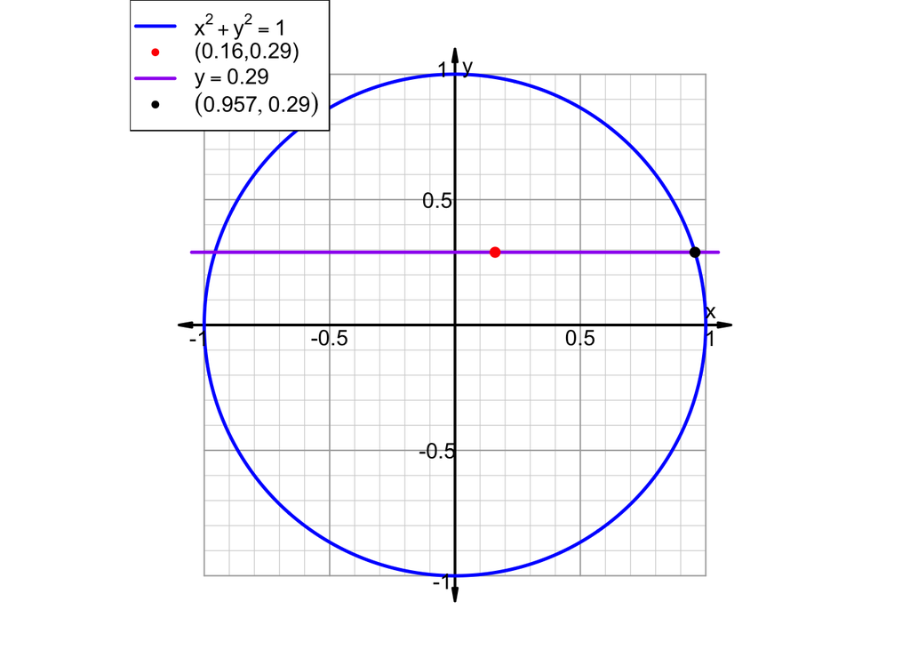

# Meta-information

extype: num exsolution: 0.9570266 exname: circ_2nd_coordinate extol: 0.001